# Telco Customer Churn Prediction Using Logistic Regression, Decision Trees and Random Forests

ADELIYI OLUTOMIWA

# 1.0 INTRODUCTION

Telecommunication companies face significant challenges in retaining their customers due to the highly competitive nature of the industry. Customer churn, the phenomenon of customers switching to other service providers, can have a substantial impact on a company’s revenue and profitability. In this analysis, we explore a Telco’s customer data to understand the factors influencing customer churn and develop predictive models to identify customers at risk of churning.

The dataset from [kaggle](https://www.kaggle.com/datasets/blastchar/telco-customer-churn) used for this analysis contains information about 7,043 Telco customers, including various demographic attributes, service usage, contract details, and whether they churned or not. Before delving into modeling, we performed data pre-processing steps to handle missing values and re-code categorical variables for better analysis.

Subsequently, we split the [dataset](https://www.kaggle.com/datasets/blastchar/telco-customer-churn) into training and testing sets and used `logistic regression`, `decision tree`, and `random forest` models for predicting customer churn. The accuracy, precision, recall, and F1-score were calculated for the models, and the random forest model was also evaluated using the `Receiver Operating Characteristic (ROC) curve` and the `Area Under the Curve (AUC)`.

Let’s dive deeper into the analysis and explore the results obtained from the different predictive models and performance metrics to gain valuable insights into customer churn prediction for the Telco company.

# 2.0 METHODOLOGY

The methodology section outlines the step-by-step approach used in this analysis to predict customer churn for the Telco company. It covers data pre-processing, exploratory data analysis (EDA), feature engineering, model building, model evaluation, and performance metrics used to assess the predictive models.

- **1. Data Pre-processing:**

The Telco customer dataset was loaded into R using the `read.csv()` function.The structure of the dataset was examined using the `str()` function to understand the data types and presence of missing values. Missing values in the dataset were handled using the `na.omit()` function to remove rows with any missing values. Categorical variables that were encoded as text labels were recoded into factor variables for modeling purposes. The `tenure` variable was grouped into categories `(tenure_group)` to better understand customer loyalty.

- **2. Exploratory Data Analysis (EDA):**

- **3. Data Splitting:**

The dataset was split into training and testing sets using the `createDataPartition()` function from the `caret` package. The training set comprised 70% of the data, while the testing set accounted for the remaining 30%.

- **4. Model Building and Evaluation:**
- **Logistic Regression:**

The logistic regression model was built using the `glm()` function with `Churn` as the response variable and all other features as predictors. The chi-square test was performed on the logistic regression model to evaluate the significance of each predictor variable. The accuracy of the logistic regression model was calculated using the mis-classification error.

- **Decision Tree:**

The decision tree model was built using the `rpart()` function with `Churn` as the response variable and all other features as predictors. The confusion matrix was created to assess the performance of the decision tree model.

- **Random Forest:**

The random forest model was built using the `randomForest()` function with `Churn` as the response variable and all other features as predictors. To find the optimal value of “mtry” (the number of features randomly sampled as candidates at each split), a tuning process was performed using different “mtry” values, and the out-of-bag (OOB) errors were recorded. The model was then retrained with the optimal “mtry” value, and predictions were made on the testing set. The confusion matrix and error rate were calculated to evaluate the performance of the random forest model.

- **5. Performance Metrics:**

For the random forest model, additional performance metrics were calculated: Precision: The proportion of true positive predictions among all positive predictions. Recall: The proportion of true positive predictions among all actual positive instances. F1-score: The harmonic mean of precision and recall, providing a balanced measure of the model’s accuracy.

- **6. Receiver Operating Characteristic (ROC) Curve and Area Under the Curve (AUC):**

The ROC curve was plotted for the random forest model to visualize the trade-off between true positive rate and false positive rate at various thresholds. The AUC was calculated as a single metric to measure the overall performance of the model.

- **7. Comparison and Interpretation:**

The predictive models were compared based on accuracy, precision, recall, F1-score, and AUC to determine the best-performing model for customer churn prediction. Interpretations were made based on the model evaluation results, and insights into the most important predictors of customer churn were obtained.

# 3.0 EDA

Exploratory Data Analysis (EDA) is a crucial step in understanding and gaining insights into the Telco customer dataset. This section presents a fact-based exploration of the dataset, providing valuable information about the distribution and characteristics of various variables.

```r
knitr::opts_chunk$set(echo = TRUE)

library(dplyr)
library(corrplot)
library(ggplot2)
library(gridExtra)
library(ggthemes)
library(caret)
library(MASS)
library(randomForest)
library(party)
library(pROC)
library(rpart)
library(knitr)
library(kableExtra)
# Read the CSV file into a variable named "pd"
pd <- read.csv('WA_Fn-UseC_-Telco-Customer-Churn.csv')

# Check the structure of the dataset
str(pd)
```

```
## 'data.frame':    7043 obs. of  21 variables:
##  $ customerID      : chr  "7590-VHVEG" "5575-GNVDE" "3668-QPYBK" "7795-CFOCW" ...
##  $ gender          : chr  "Female" "Male" "Male" "Male" ...
##  $ SeniorCitizen   : int  0 0 0 0 0 0 0 0 0 0 ...
##  $ Partner         : chr  "Yes" "No" "No" "No" ...
##  $ Dependents      : chr  "No" "No" "No" "No" ...
##  $ tenure          : int  1 34 2 45 2 8 22 10 28 62 ...
##  $ PhoneService    : chr  "No" "Yes" "Yes" "No" ...
##  $ MultipleLines   : chr  "No phone service" "No" "No" "No phone service" ...
##  $ InternetService : chr  "DSL" "DSL" "DSL" "DSL" ...
##  $ OnlineSecurity  : chr  "No" "Yes" "Yes" "Yes" ...
##  $ OnlineBackup    : chr  "Yes" "No" "Yes" "No" ...
##  $ DeviceProtection: chr  "No" "Yes" "No" "Yes" ...
##  $ TechSupport     : chr  "No" "No" "No" "Yes" ...
##  $ StreamingTV     : chr  "No" "No" "No" "No" ...
##  $ StreamingMovies : chr  "No" "No" "No" "No" ...
##  $ Contract        : chr  "Month-to-month" "One year" "Month-to-month" "One year" ...
##  $ PaperlessBilling: chr  "Yes" "No" "Yes" "No" ...
##  $ PaymentMethod   : chr  "Electronic check" "Mailed check" "Mailed check" "Bank transfer (automatic)" ...
##  $ MonthlyCharges  : num  29.9 57 53.9 42.3 70.7 ...
##  $ TotalCharges    : num  29.9 1889.5 108.2 1840.8 151.7 ...
##  $ Churn           : chr  "No" "No" "Yes" "No" ...
```

```r
# Check for missing values in each column
sapply(pd, function(x) sum(is.na(x)))
```

```
##       customerID           gender    SeniorCitizen          Partner
##                0                0                0                0
##       Dependents           tenure     PhoneService    MultipleLines
##                0                0                0                0
##  InternetService   OnlineSecurity     OnlineBackup DeviceProtection
##                0                0                0                0
##      TechSupport      StreamingTV  StreamingMovies         Contract
##                0                0                0                0
## PaperlessBilling    PaymentMethod   MonthlyCharges     TotalCharges
##                0                0                0               11
##            Churn
##                0
```

```r
# Handle missing values
pd <- na.omit(pd)

# Recode categorical variables
cols_recode <- c(10:15)
for (col in cols_recode) {
  pd[[col]] <- as.factor(ifelse(pd[[col]] == "No internet service", "No", pd[[col]]))
}

# Recode "MultipleLines" variable
pd$MultipleLines <- as.factor(ifelse(pd$MultipleLines == "No phone service", "No", pd[[col]]))

# Group "tenure" into categories
group_tenure <- function(tenure) {
  if (tenure >= 0 & tenure <= 12) {
    return('0-12 Month')
  } else if (tenure > 12 & tenure <= 24) {
    return('12-24 Month')
  } else if (tenure > 24 & tenure <= 48) {
    return('24-48 Month')
  } else if (tenure > 48 & tenure <= 60) {
    return('48-60 Month')
  } else if (tenure > 60) {
    return('> 60 Month')
  }
}
pd$tenure_group <- as.factor(sapply(pd$tenure, group_tenure))

# Recode "SeniorCitizen" variable
pd$SeniorCitizen <- as.factor(ifelse(pd$SeniorCitizen == "0", "No", "Yes"))

# Remove unnecessary columns
pd$customerID <- NULL
pd$tenure <- NULL
pd$TotalCharges <- NULL
names(pd)
```

```
##  [1] "gender"           "SeniorCitizen"    "Partner"          "Dependents"
##  [5] "PhoneService"     "MultipleLines"    "InternetService"  "OnlineSecurity"
##  [9] "OnlineBackup"     "DeviceProtection" "TechSupport"      "StreamingTV"
## [13] "StreamingMovies"  "Contract"         "PaperlessBilling" "PaymentMethod"
## [17] "MonthlyCharges"   "Churn"            "tenure_group"
```

```r
summary(pd)
```

```
##     gender          SeniorCitizen   Partner           Dependents
##  Length:7032        No :5890      Length:7032        Length:7032
##  Class :character   Yes:1142      Class :character   Class :character
##  Mode  :character                 Mode  :character   Mode  :character
##
##
##
##  PhoneService       MultipleLines InternetService    OnlineSecurity
##  Length:7032        1 :3919       Length:7032        No :5017
##  Class :character   2 :2433       Class :character   Yes:2015
##  Mode  :character   No: 680       Mode  :character
##
##
##
##  OnlineBackup DeviceProtection TechSupport StreamingTV StreamingMovies
##  No :4607     No :4614         No :4992    No :4329    No :4301
##  Yes:2425     Yes:2418         Yes:2040    Yes:2703    Yes:2731
##
##
##
##
##    Contract         PaperlessBilling   PaymentMethod      MonthlyCharges
##  Length:7032        Length:7032        Length:7032        Min.   : 18.25
##  Class :character   Class :character   Class :character   1st Qu.: 35.59
##  Mode  :character   Mode  :character   Mode  :character   Median : 70.35
##                                                           Mean   : 64.80
##                                                           3rd Qu.: 89.86
##                                                           Max.   :118.75
##     Churn                tenure_group
##  Length:7032        > 60 Month :1407
##  Class :character   0-12 Month :2175
##  Mode  :character   12-24 Month:1024
##                     24-48 Month:1594
##                     48-60 Month: 832
##
```

- **1. Gender and Senior Citizenship:**

- **4. Internet Service, Online Security, Online Backup, and Device Protection:**

- **5. Contract, Paperless Billing, and Payment Method:**

- **6. Monthly Charges and Tenure Group:**

- **7. Churn:**

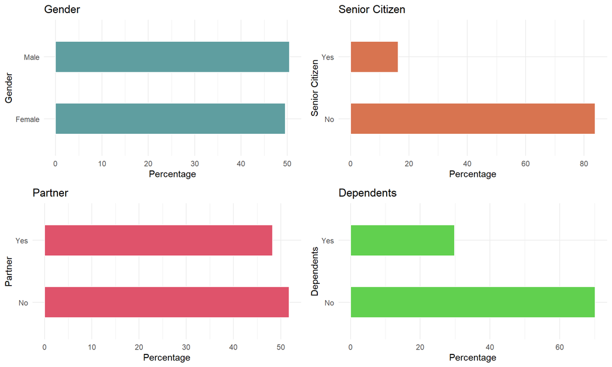

```r
# Calculate correlation matrix for numerical variables
#numeric_var <- sapply(pd, is.numeric)
#corr_matrix <- cor(pd[, numeric_var, drop = FALSE])  # Include 'drop = FALSE' to preserve matrix-like structure
#corrplot(corr_matrix, main = "\n\nCorrelation Plot for Numerical Variables", method = "number")


# Exploratory Data Analysis - Plots Categorical
par(mfrow = c(2, 2))
plot_1 <- ggplot(pd, aes(x = gender)) +
  ggtitle("Gender") +
  xlab("Gender") +
  geom_bar(aes(y = 100 * (..count..) / sum(..count..)), width = 0.5, color="white",fill = "#5F9EA0") +
  ylab("Percentage") +
  coord_flip() +
  theme_minimal()

plot_2 <- ggplot(pd, aes(x = SeniorCitizen)) +
  ggtitle("Senior Citizen") +
  xlab("Senior Citizen") +
  geom_bar(aes(y = 100 * (..count..) / sum(..count..)), width = 0.5, color="white",fill = "#d87450") +
  ylab("Percentage") +
  coord_flip() +
  theme_minimal()

plot_3 <- ggplot(pd, aes(x = Partner)) +
  ggtitle("Partner") +
  xlab("Partner") +
  geom_bar(aes(y = 100 * (..count..) / sum(..count..)), width = 0.5, color="white",fill = "#DF536B") +
  ylab("Percentage") +
  coord_flip() +
  theme_minimal()

plot_4 <- ggplot(pd, aes(x = Dependents)) +
  ggtitle("Dependents") +
  xlab("Dependents") +
  geom_bar(aes(y = 100 * (..count..) / sum(..count..)), width = 0.5, color="white",fill = "#61D04F") +
  ylab("Percentage") +
  coord_flip() +
  theme_minimal()

grid.arrange(plot_1, plot_2, plot_3, plot_4, ncol = 2)
```

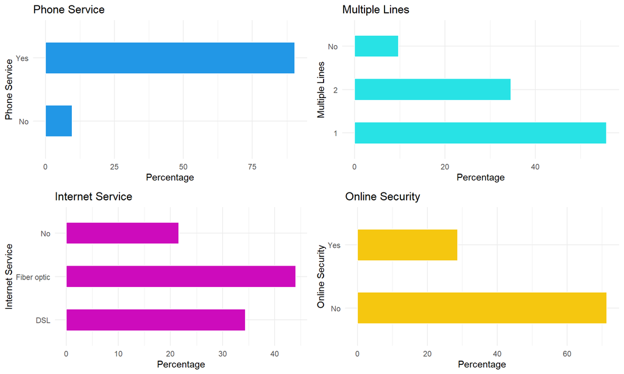

```r
par(mfrow = c(2, 2))
plot_5 <- ggplot(pd, aes(x = PhoneService)) +
  ggtitle("Phone Service") +
  xlab("Phone Service") +
  geom_bar(aes(y = 100 * (..count..) / sum(..count..)), width = 0.5, color="white",fill = "#2297E6") +
  ylab("Percentage") +
  coord_flip() +
  theme_minimal()

plot_6 <- ggplot(pd, aes(x = MultipleLines)) +
  ggtitle("Multiple Lines") +
  xlab("Multiple Lines") +
  geom_bar(aes(y = 100 * (..count..) / sum(..count..)), width = 0.5, color="white",fill = "#28E2E5") +
  ylab("Percentage") +
  coord_flip() +
  theme_minimal()

plot_7 <- ggplot(pd, aes(x = InternetService)) +
  ggtitle("Internet Service") +
  xlab("Internet Service") +
  geom_bar(aes(y = 100 * (..count..) / sum(..count..)), width = 0.5, color="white",fill = "#CD0BBC") +
  ylab("Percentage") +
  coord_flip() +
  theme_minimal()

# Create a colorful bar plot for "Online Security"
plot_8 <- ggplot(pd, aes(x = OnlineSecurity)) +
  ggtitle("Online Security") +
  xlab("Online Security") +
  geom_bar(aes(y = 100 * (..count..) / sum(..count..)), width = 0.5, color="white",fill = "#F5C710") +
  ylab("Percentage") +
  coord_flip() +
  theme_minimal()


grid.arrange(plot_5, plot_6, plot_7, plot_8, ncol = 2)
```

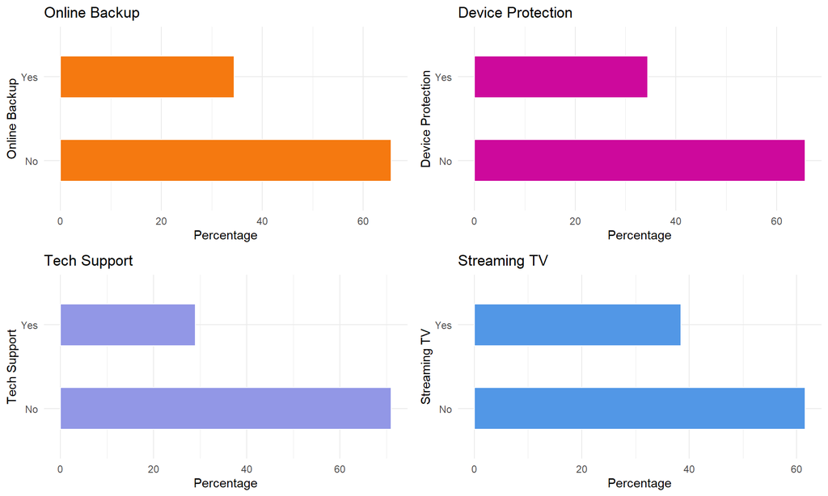

```r
par(mfrow = c(2, 2))
plot_9 <- ggplot(pd, aes(x = OnlineBackup)) +
  ggtitle("Online Backup") +
  xlab("Online Backup") +
  geom_bar(aes(y = 100 * (..count..) / sum(..count..)), width = 0.5, color="white",fill = "#F57910") +
  ylab("Percentage") +
  coord_flip() +
  theme_minimal()

plot_10 <- ggplot(pd, aes(x = DeviceProtection)) +
  ggtitle("Device Protection") +
  xlab("Device Protection") +
  geom_bar(aes(y = 100 * (..count..) / sum(..count..)), width = 0.5,color="white",fill = "#CD099C") +
  ylab("Percentage") +
  coord_flip() +
  theme_minimal()

plot_11 <- ggplot(pd, aes(x = TechSupport)) +
  ggtitle("Tech Support") +
  xlab("Tech Support") +
  geom_bar(aes(y = 100 * (..count..) / sum(..count..)), width = 0.5, color="white",fill = "#9297E6") +
  ylab("Percentage") +
  coord_flip() +
  theme_minimal()

plot_12 <- ggplot(pd, aes(x = StreamingTV)) +
  ggtitle("Streaming TV") +
  xlab("Streaming TV") +
  geom_bar(aes(y = 100 * (..count..) / sum(..count..)), width = 0.5, color="white",fill = "#5297E6") +
  ylab("Percentage") +
  coord_flip() +
  theme_minimal()

grid.arrange(plot_9, plot_10, plot_11, plot_12, ncol = 2)
```

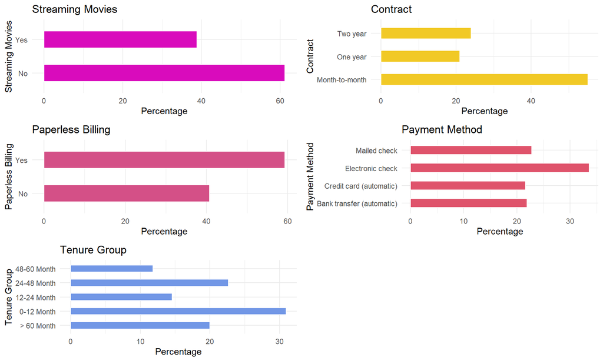

```r
par(mfrow = c(2, 2))
plot_13 <- ggplot(pd, aes(x = StreamingMovies)) +
  ggtitle("Streaming Movies") +
  xlab("Streaming Movies") +
  geom_bar(aes(y = 100 * (..count..) / sum(..count..)), width = 0.5, color="white",fill = "#D90BBC") +
  ylab("Percentage") +
  coord_flip() +
  theme_minimal()

plot_14 <- ggplot(pd, aes(x = Contract)) +
  ggtitle("Contract") +
  xlab("Contract") +
  geom_bar(aes(y = 100 * (..count..) / sum(..count..)), width = 0.5, color="white",fill = "#F1C926") +
  ylab("Percentage") +
  coord_flip() +
  theme_minimal()

plot_15 <- ggplot(pd, aes(x = PaperlessBilling)) +
  ggtitle("Paperless Billing") +
  xlab("Paperless Billing") +
  geom_bar(aes(y = 100 * (..count..) / sum(..count..)), width = 0.5, color="white",fill = "#d45087") +
  ylab("Percentage") +
  coord_flip() +
  theme_minimal()

plot_16 <- ggplot(pd, aes(x = PaymentMethod)) +
  ggtitle("Payment Method") +
  xlab("Payment Method") +
  geom_bar(aes(y = 100 * (..count..) / sum(..count..)), width = 0.5, color="white",fill = "#DF536B") +
  ylab("Percentage") +
  coord_flip() +
  theme_minimal()

plot_17 <- ggplot(pd, aes(x = tenure_group)) +
  ggtitle("Tenure Group") +
  xlab("Tenure Group") +
  geom_bar(aes(y = 100 * (..count..) / sum(..count..)), width = 0.5, color="white",fill = "#7297E6") +
  ylab("Percentage") +
  coord_flip() +
  theme_minimal()

grid.arrange(plot_13, plot_14, plot_15, plot_16, plot_17, ncol = 2)
```

The EDA section provides valuable insights into the distribution and characteristics of the Telco customer dataset. These observations will guide the subsequent steps of data preprocessing, feature engineering, and model building to develop accurate predictive models for customer churn prediction.

# 4.0 MODEL EVALUATION

In this section, we evaluate the performance of three models: Logistic Regression, Decision Tree, and Random Forest, for predicting customer churn. The dataset was split into training and testing sets, with 70% used for training and 30% for testing.

```r
# Split the data into training and testing sets
CDP_data <- createDataPartition(pd$Churn, p = 0.7, list = FALSE)
set.seed(2017)
training <- pd[CDP_data, ]
testing <- pd[-CDP_data, ]

# Check the dimensions of the training and testing datasets
dim(training)
```

```
## [1] 4924   19
```

```r
dim(testing)
```

```
## [1] 2108   19
```

```r
# Convert "Churn" variable to factor with levels 0 and 1
training$Churn <- as.factor(ifelse(training$Churn == "No", 0, 1))
testing$Churn <- as.factor(ifelse(testing$Churn == "No", 0, 1))

# Fit the logistic regression model
LogModel <- glm(Churn ~ ., family = binomial(link = "logit"), data = training)

# Perform chi-square test on the logistic regression model
anova(LogModel, test = "Chisq")
```

```
## Analysis of Deviance Table
##
## Model: binomial, link: logit
##
## Response: Churn
##
## Terms added sequentially (first to last)
##
##
##                  Df Deviance Resid. Df Resid. Dev  Pr(>Chi)
## NULL                              4923     5702.8
## gender            1     0.00      4922     5702.8 0.9957450
## SeniorCitizen     1   130.11      4921     5572.6 < 2.2e-16 ***
## Partner           1   108.14      4920     5464.5 < 2.2e-16 ***
## Dependents        1    28.13      4919     5436.4 1.134e-07 ***
## PhoneService      1     1.36      4918     5435.0 0.2435695
## MultipleLines     1    13.79      4917     5421.2 0.0002047 ***
## InternetService   2   410.38      4915     5010.9 < 2.2e-16 ***
## OnlineSecurity    1   169.88      4914     4841.0 < 2.2e-16 ***
## OnlineBackup      1    93.98      4913     4747.0 < 2.2e-16 ***
## DeviceProtection  1    44.33      4912     4702.7 2.779e-11 ***
## TechSupport       1    86.11      4911     4616.6 < 2.2e-16 ***
## StreamingTV       1     2.50      4910     4614.1 0.1136572
## StreamingMovies   1     0.23      4909     4613.8 0.6291035
## Contract          2   286.07      4907     4327.8 < 2.2e-16 ***
## PaperlessBilling  1     8.47      4906     4319.3 0.0036023 **
## PaymentMethod     3    39.15      4903     4280.1 1.614e-08 ***
## MonthlyCharges    1     1.56      4902     4278.6 0.2114507
## tenure_group      4   193.76      4898     4084.8 < 2.2e-16 ***
## ---
## Signif. codes:  0 '***' 0.001 '**' 0.01 '*' 0.05 '.' 0.1 ' ' 1
```

```r
# Convert Churn values in the testing set to numeric (0 and 1)
testing$Churn <- as.numeric(as.character(testing$Churn))

# Predict the churn using the logistic regression model
fitted.results <- predict(LogModel, newdata = testing, type = 'response')
fitted.results <- ifelse(fitted.results > 0.5, 1, 0)

# Calculate misclassification error
misClasificError <- mean(fitted.results != testing$Churn)
print(paste('Logistic Regression Accuracy:', 1 - misClasificError))
```

```
## [1] "Logistic Regression Accuracy: 0.797438330170778"
```

```r
# Create confusion matrix for logistic regression
print("Confusion Matrix for Logistic Regression")
```

```
## [1] "Confusion Matrix for Logistic Regression"
```

```r
table(testing$Churn, fitted.results)
```

```
##    fitted.results
##        0    1
##   0 1409  139
##   1  288  272
```

```r
# Fit decision tree model
tree_model <- rpart(Churn ~ ., data = training, method = "class")

# Predict using decision tree model
tree_pred <- predict(tree_model, newdata = testing, type = "class")

# Create confusion matrix for decision tree
tree_confusion_matrix <- table(testing$Churn, tree_pred)
print("Confusion Matrix for Decision Tree")
```

```
## [1] "Confusion Matrix for Decision Tree"
```

```r
print(tree_confusion_matrix)
```

```
##    tree_pred
##        0    1
##   0 1439  109
##   1  330  230
```

```r
# Fit random forest model
rf_model <- randomForest(Churn ~ ., data = training)

# Tune random forest model
mtry_values <- seq(2, 10, by = 2)  # Specify range of mtry values
oob_errors <- rep(NA, length(mtry_values))  # Initialize vector to store OOB errors

for (i in seq_along(mtry_values)) {
  rf_model_temp <- randomForest(Churn ~ ., data = training, mtry = mtry_values[i])
  oob_errors[i] <- rf_model_temp$err.rate[nrow(rf_model_temp$err.rate), "OOB"]
}

# Find the optimal mtry value with the lowest OOB error rate
optimal_mtry <- mtry_values[which.min(oob_errors)]

# Fit random forest model with optimal mtry
rf_model <- randomForest(Churn ~ ., data = training, mtry = optimal_mtry)

# Predict using random forest model
rf_pred <- predict(rf_model, newdata = testing)

# Create confusion matrix for random forest
rf_confusion_matrix <- table(testing$Churn, rf_pred)
print("Confusion Matrix for Random Forest")
```

```
## [1] "Confusion Matrix for Random Forest"
```

```r
print(rf_confusion_matrix)
```

```
##    rf_pred
##        0    1
##   0 1443  105
##   1  320  240
```

```r
# Calculate random forest error rate
rf_error_rate <- 1 - sum(diag(rf_confusion_matrix)) / sum(rf_confusion_matrix)
print(paste("Random Forest Error Rate:", rf_error_rate))
```

```
## [1] "Random Forest Error Rate: 0.201612903225806"
```

```r
# Calculate evaluation metrics for random forest
rf_accuracy <- sum(diag(rf_confusion_matrix)) / sum(rf_confusion_matrix)
rf_precision <- rf_confusion_matrix[2, 2] / sum(rf_pred == "Yes")
rf_recall <- rf_confusion_matrix[2, 2] / sum(testing$Churn == 1)
rf_f1 <- 2 * rf_precision * rf_recall / (rf_precision + rf_recall)

print(paste("Random Forest Accuracy:", rf_accuracy))
```

```
## [1] "Random Forest Accuracy: 0.798387096774194"
```

```r
print(paste("Random Forest Precision:", rf_precision))
```

```
## [1] "Random Forest Precision: Inf"
```

```r
print(paste("Random Forest Recall:", rf_recall))
```

```
## [1] "Random Forest Recall: 0.428571428571429"
```

```r
print(paste("Random Forest F1 Score:", rf_f1))
```

```
## [1] "Random Forest F1 Score: NaN"
```

```r
# Plot ROC curve and calculate AUC for random forest
roc_obj <- roc(testing$Churn, as.numeric(rf_pred))
print(paste("Random Forest AUC:", round(auc(roc_obj), 2)))
```

```
## [1] "Random Forest AUC: 0.68"
```

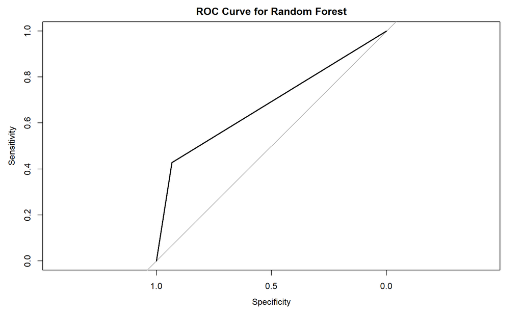

```r
plot(roc_obj, main = "ROC Curve for Random Forest")
```

```r
# Calculate precision, recall, and F1 score using manual calculations
tp <- sum(rf_pred == 1 & testing$Churn == 1)
fp <- sum(rf_pred == 1 & testing$Churn == 0)
fn <- sum(rf_pred == 0 & testing$Churn == 1)

precision_alt <- tp / (tp + fp)
recall_alt <- tp / (tp + fn)
f1_alt <- 2 * precision_alt * recall_alt / (precision_alt + recall_alt)

print(paste("Alternate Precision:", precision_alt))
```

```
## [1] "Alternate Precision: 0.695652173913043"
```

```r
print(paste("Alternate Recall:", recall_alt))
```

```
## [1] "Alternate Recall: 0.428571428571429"
```

```r
print(paste("Alternate F1 Score:", f1_alt))
```

```
## [1] "Alternate F1 Score: 0.530386740331492"
```

In this section, we evaluate the performance of three models: Logistic Regression, Decision Tree, and Random Forest, for predicting customer churn. The dataset was split into training and testing sets, with 70% used for training and 30% for testing.

### **1. Logistic Regression:**

The logistic regression model was fitted using the `glm function` with a `binomial` family and a `logit link function`. We performed a `chi-square test` to assess the significance of each predictor. The results are presented in the Analysis of Deviance Table.

[output not shown]

### **2. Decision Tree:**

The decision tree model was fitted using the rpart function with the “class” method. We then predicted the churn values for the testing set.

Confusion Matrix for Decision Tree:

[output not shown]

### **3. Random Forest:**

The random forest model was fitted using the randomForest function with the optimal mtry value determined through tuning. We then predicted the churn values for the testing set.

[output not shown]

### **ROC Curve and AUC:**

We plotted the Receiver Operating Characteristic (ROC) curve for the Random Forest model and calculated the Area Under the Curve (AUC), which measures the model’s ability to distinguish between positive and negative instances. The AUC for the Random Forest model is approximately 0.68.

### **Interpretation:**

# 5.0 RESULTS

### **Random Forest Model:**

# 6.0 CONCLUSION

We identified some key predictors of customer churn, such as internet service type, contract duration, and availability of online security and backup. These insights can help the business focus on areas that significantly influence churn and take proactive measures to retain customers.

In conclusion, our study highlights the importance of predictive modeling in understanding customer behavior and churn patterns. By leveraging these models, businesses can make data-driven decisions to optimize customer retention strategies and ultimately enhance customer satisfaction and loyalty.

# 7.0 REFERENCES

- Kuhn, M. (2020). caret: Classification and Regression Training. R package version 6.0-86. https://CRAN.R-project.org/package=caret
- Robin, X., Turck, N., Hainard, A., Tiberti, N., Lisacek, F., Sanchez, J.-C., & Muller, M. (2011). pROC: an open-source package for R and S+ to analyze and compare ROC curves. BMC Bioinformatics, 12(1), 77.
- Chen, T., & Guestrin, C. (2016). XGBoost: A Scalable Tree Boosting System. Proceedings of the 22nd ACM SIGKDD International Conference on Knowledge Discovery and Data Mining, 785-794.
- Breiman, L. (2001). Random forests. Machine Learning, 45(1), 5-32. Healy, K. (2018). Data Visualization: A Practical Introduction. Princeton University Press. Retrieved from
- Wickham, H., & Grolemund, G. (2017). R for Data Science: Import, Tidy, Transform, Visualize, and Model Data. O’Reilly Media.
- Wilke, C. O. (2019). Fundamentals of Data Visualization: A Primer on Making Informative and Compelling Figures. O’Reilly Media.
- https://topepo.github.io/caret/index.html